# FANR 8950, Fall 2025 - Final Project

Kimberly Garcia

2025-12-04

# INTRODUCTION

This report summarizes the preliminary results of the project **“Taxonomic diversity of Cerambycidae beetles in fragments of Tropical Dry Forest in the Caribbean of Colombia.”**

We sampled a total of five localities in the Caribbean of Colombia which are as follows:

RM: Reserva la Montaña (Atlántico); SC: Santa Catalina (Atlántico); LR: Los Rosales (Atlántico); SFFC: Santuario de Flora y Fauna los Colorados (Bolívar); RLF: Reserva La Flecha (Bolívar).

Additionally, in the SFFC we compared between two different types of habitat, forest and a recovering buffer zone.

For this report, richness is calculated as number of species captured by locality, and abundance is calculated as number of individuals by locality. Diversity is estimated following Chao and collaborators’ Hill numbers, which consider “effective number of species”. Accordingly Hill 0 is total species richness, Hill 1 is Shannon entropy and Hill 2 is inverse Simpson (Chao *et al*., 2014).

# DATA EXPLORATION

For the elaboration of this report, I started with three datasets, a general matrix containing the number of individuals captured by species in each location, plot and month; a table with the biomass of each species in each habitat sampled in the SFFC; and a table with the corresponding subfamily of each species collected in the SFFC.

I subset the general matrix to the SFFC data only, for further evaluation of this data. The columns that has no data (species that were only sampled in the other localities) were filtered out.

Then I performed some data cleaning, focusing on the unification of species names across datasets because for example, in some they had spaces, underscores, dots, etc. I also identified some typos and corrected it during this step. This step was crucial for future analysis of joint datasets.

I did some extra data cleaning in the SFFC dataset: First, by pivoting all the columns of species to one only species column and one abundance column. I also changed the name of some columns that were initially in spanish. Lastly, as the original matrix has information about plot and month, I summarized to consider the two habitats only.

After all data frames had the same format, I joined all three of them resulting in one only matrix with abundance, biomass and subfamily data. In some cases, some species did not have biomass information, I filtered them out. I also needed to change biomass data to numeric for further analysis.

After having all my data cleaned and organized, I prepared some data for later use in the data visualization:

1. I want to provide a list of the species organized by their abundance (from less to most abundant), so I created a factor and organized it by their abundance.
2. I want to provide the number of singletones and doubletones collected in the SFFC, so I created a function that counts the species that has only one or two representatives.
3. I wanted to present a summarized table, that shows total richness, abundance, biomass and other parameters by locality in SFFC, so I created a new matrix with this information, and later on I did a table.
4. I wanted to count how many species had their abundance above and below the mean, so I calculated the mean of the abundance and then created a for loop, with an If statement to create a vector that keep those counts. e.g. For each abundance value, if it is above the mean, keep it in the vector “above”, if is not, keep it in the vector “below”.
5. Lastly, I wanted to know how many individuals by family were collected in each locality, so I nested the matrix that contains the subfamily info into the table that was summarized by locality. Then I was able to make a histogram that shows the total abundance of each subfamily by habitat.

Although most of the analysis performed in this report are for the SFFC locality, I decided to include some analysis to all the localities. I estimated the diversity using Hill numbers with the package hillR by Chao et al. (2014). I had to transform the general matrix so it has the format that the package requested (a row per locality), and then I created a for loop so it calculates each Hill number (0, 1 and 2) to each locality. This information was later used for a graph.

Lastly, for the general analysis that contains all localities, I wanted to compare their abundance and richness, so format the matrix to be able to calculate these variables.

All the code used for data cleaning, exploration and functions can be found at the repository code.

# DATA SUMMARY

## Cerambycidae diversity in five fragments of Tropical Dry forest

### Results

We sampled a total of 189 individuals which belong to 131 species and three subfamilies, in the five sampled locations. The abundance was distinctly higher in SFFC compared to the other localities, comprising more than half of the total abundance. The least abundant locality was LR with under 10 individuals (Fig. 1).

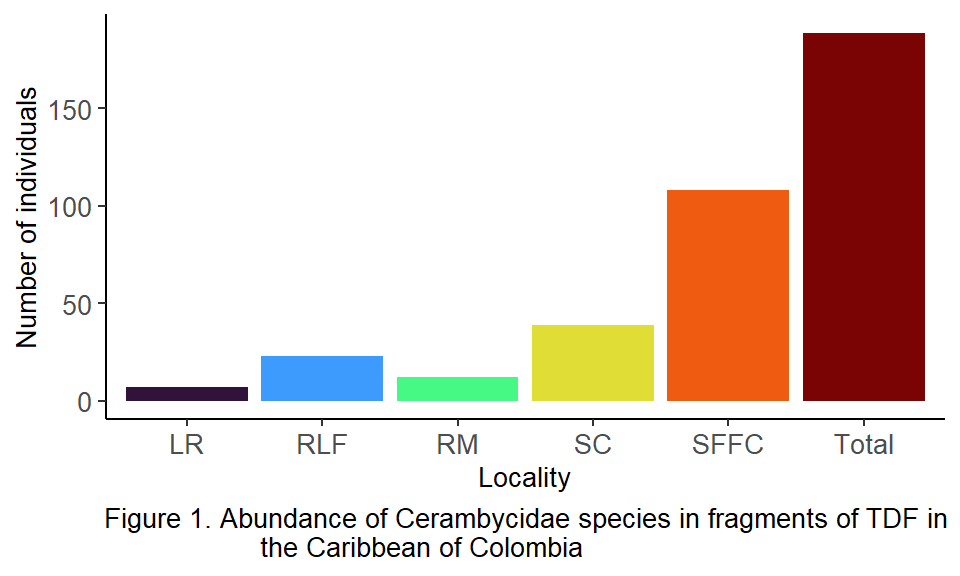

Regarding richness, it follows the same pattern than abundance, having the highest richness in SFFC, followed by SC, RLF, RM and lastly, LR (Fig. 2).

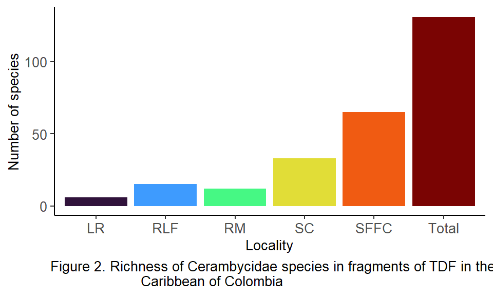

I calculated the diversity through Hill Numbers (Fig. 3). As expected, for q= 0, diversity was distinctly higher in SFFC, as it is the total richness, being almost double than the following in higher richness SC (Fig. 3a).

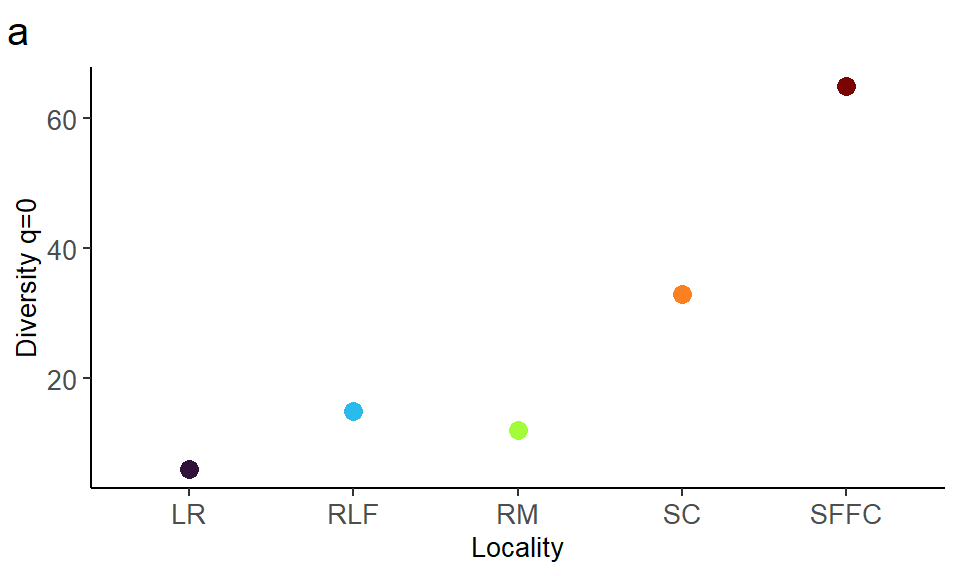

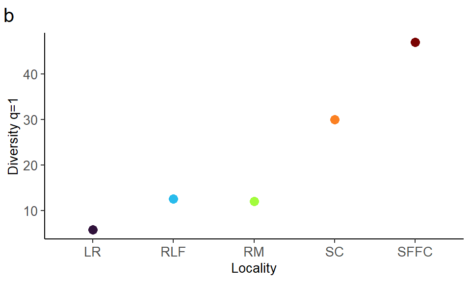

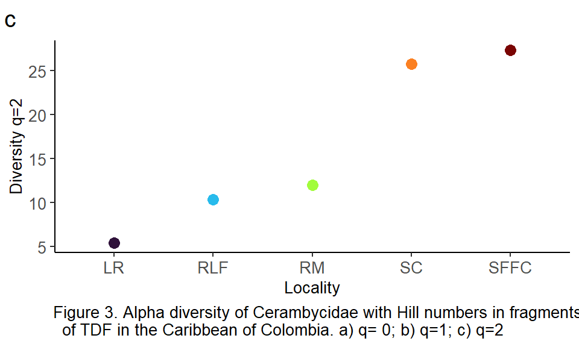

When considering common species (q= 1), the numbers even a little more, but follow the same pattern with SFFC with the highest diversity (Fig. 3b). Lastly, when considering the dominant species (q= 2), the numbers even a lot more, there is not as big differences as in q= 0, and although SFFC is still the highest, it is very close to SC (Fig. 3C).

### Conclusions

Among all the localities, SFFC shows a higher diversity, abundance and richness, followed by SC by far. This is very interesting given that SFFC is one of the few locations of TDF in Colombia that is under protection, and the study area is currently undergoing a recovery treatment (Parques Nacionales Naturales de Colombia, 2024). Cerambycidae species are known to be good indicators of their ecosystem health, because their diversity is affected under habitat stress that decreases their feeding and reproduction resources (Hjältén *et al*., 2012).

Therefore, having a higher diversity associated with a protected area is showing that the actions performed to recover and protect the forests are giving good results, because the high diversity of Cerambycidae species suggest a healthy ecosystem.

We aim that this results demonstrate to decision makers the importance of making efforts in other TDF fragments as their diversity is clearly under threat, specially in localities like LR, RLF and RM.

## Cerambycidae diversity in two habitats within TDF fragment, forest and buffer zone.

### Results

We sampled on both the forest fragment and the buffer zone, to compare the abundance, richness, diversity and biomass in each one (Table 1).

Table 1. Richness, abundance and biomass parameters for Cerambycidae species in two habitats (buffer zone and forest) in a fragment of TDF (SFFC). SD: Standard deviation; ABC: Abundance/Biomass Comparison; sp bm ratio: species/biomass ratio

| Locality | Richness | Abundance | Biomass | Mean biomass | SD biomass | ABC | sp bm ratio |
| --- | --- | --- | --- | --- | --- | --- | --- |
| SFFC buffer zone | 34 | 56 | 6.110 | 0.180 | 0.359 | 9.165 | 5.564 |
| SFFC forest | 30 | 46 | 8.001 | 0.267 | 0.813 | 5.749 | 3.750 |

The abundance in SFFC was the highest in our study and it is mainly represented by singletones and doubletones, with a total of 44 singletones and 16 doubletones. Not surprisingly the mean abundance is 1.59375 with 20 species above the mean and 44 species below the mean, showing the high amount of a single representative.

The Cerambycidae species that were collected in SFFC, organized by their abundance are as follow:

*Adetus tayronus, Aphies erythrodera, Beraba limpida, Beraba sp, Caciomorpha palliata, Carphina arcifera, Chrysoprasis chevrolati, Coleoxestia atrata, Desmiphora canescens, Diploschema mandibulare, Eburodacrys asperula, Estola vulgaris, Gnomibidion cylindricum, Gnomidolon bellus, Gorybia armata, Gorybia martes, Heterachthes lateralis, Heterachthes sp, Hippopsis albicans, Leptostylus carinatus, Lepturges circumscripta, Lepturges sp2, Lepturges sp3, Lophopoeum carinatulum, Myoxinus pictus, Neocompsa glaphyra, Neoptychodes trilineatus, Oedopeza cryptica, Oedopeza ocellator, Oreodera howdeni, Oxymerus aculeatus lebasi, Pantomallus martinezi, Phaea sondenegro, Poeciloxestia paraensis, Psyrassa xestioides, Ptychodes taeniotoides taeniotoides, Steinheilia mandibularis, Taurolema flavocincta, Trachyderes melas, Tropidion sp, Ancylosternus morio albicornis, Atrypanius lignarius, Chlorida festiva, Eupogonius subaeneus, Harringtonia dalmeidai, Hippopsis lemniscata, Irundisaua moacyri, Lepturges sp1, Limernaea ochracea, Mallodon dasystomus, Nealcidion socium, Parastizocera procera, Tapeina erectifrons erectifrons, Tulcus picticornis, Tulcus tigrinatus, Zeale scalaris, Lagocheirus araneiformis, Dorcasta dasycera, Ceragenia insulana*.

Most of these species as mentioned above were found only once, while the community is dominated by the last two species in the list.

When comparing both habitats, the buffer zone had slightly higher richness (34) and abundance (56) than the forest (30 and 46 respectively) (Fig. 4 and Fig. 5).

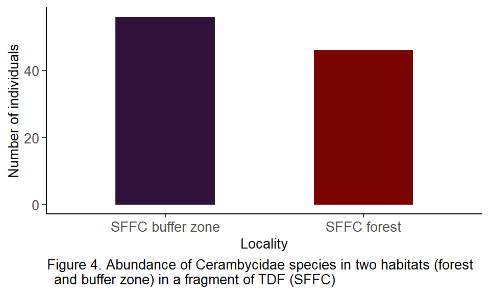

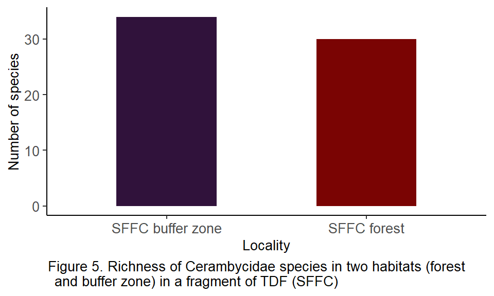

I also analyzed the biomass of these species in each locality (Fig. 6). The biomass in opposite than the abundance is greater in the forest than in the buffer zone, although is fairly close (Table 1). However, when analyzing the distribution of the biomass, the forest presents outliers, which increase the total biomass, and the buffer zone presents a more even distribution of this measure (Fig. 6).

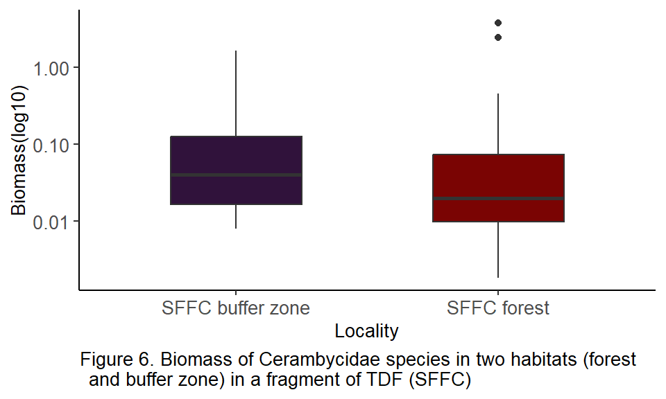

The relation between biomass and the other variables (abundance and richness) was addressed by calculating their ratio (Table 1), and both proportions were higher in the buffer zone than in the forest habitat consistent with previous results.

Lastly, I was interested in evaluating if the abundance of the subfamilies was variable between habitats, and surprisingly, we found that in the buffer zone the most abundant subfamily is Lamiinae, while in forest it is Cerambycinae (Fig. 7).

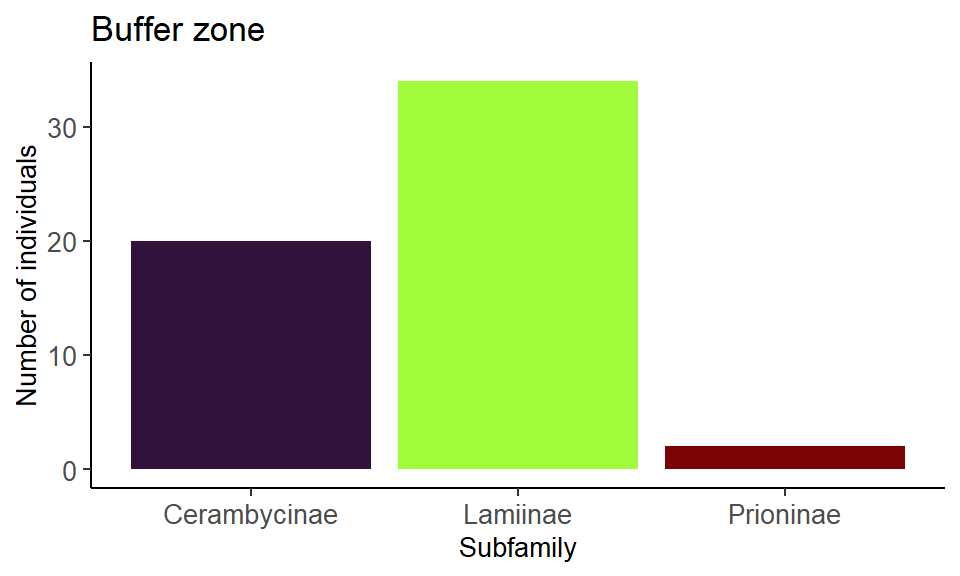

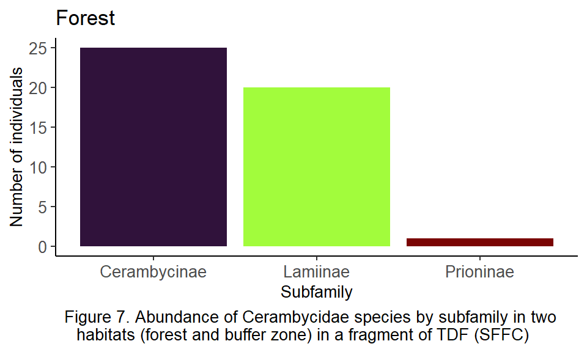

### Conclusions

I made further analyses in the most diverse locality we sampled, the SFFC. The TDF in SFFC is currently under threat, so as a conservation measure, local authorities had started a recovery area with a buffer zone adjacent to the forest fragment. As Cerambycidae species are known to be conservation indicators (Hjältén *et al*. 2012), I compared the abundance, richness and biomass between forest and buffer habitats.

As expected, the community is characterized for a high number of rare species, this is consistent with the findings of García *et al*. (2021) which found a high number of singletones and doubletones in two fragments of TDF in the Caribbean of Colombia. Also, according to Cava *et al*. (2015) this is a common find in Neotropical Arthropods.

When evaluating the abundance and richness of the Cerambycidae community, the buffer zone showed to have higher values than the forest. This results suggest that the buffer zone is acting like a ecological border between the forest and the urban area, comprising characteristics from both types of habitat, and its own, providing more resources to a higher quantity of species and individuals (Smith & Smith, 2007). This result is consistent with the findings of Alvaréz-Ramon *et al*. (2022), which report a higher number of Cerambycidae associated to a border area.

However, the number of species and individuals alone is not enough to truly understand the dynamic undergoing the Cerambycidae community, that is why we decided to also study their biomass. The biomass provides insights about the contribution of each habitat in terms of energy flux (Saint-Germain *et al*., 2007).

This higher biomass of the forest is probably related with the outliers shown in the biomass boxplot, which we conclude is a result of the high abundance of a select number of species, including *Ceragenia insulana* and *Dorcasta dasycera*. This shows that the forest still hosts the optimal resources for some species to reach their high peak of abundance, probably due to the presence of layered vegetation (Knuff *et al*., 2020). This highlights the importance to protect and recover the forest.

Lastly, given the differences in the natural history between the subfamilies of Cerambycidae, I analyzed their abundance in each habitat. I found Lamiinae to be more abundant in the buffer zone, suggesting a generalist behavior, able to adapt to all types of resources, and not depend on only the ones offered in the forest. Further studies on the habitat specialization of the species that compose Lamiinae subfamily are highly recommended to confirm this hypothesis.

The results of this study highlights the importance of establishing buffer zones as a part of the recovery of a forest in restoration because it provides an optimal habitat for the species to transition to the primary forest. We expect that with this results people will see the importance of recovering our threat ecosystems and monitoring the biodiversity of groups like Cerambycidae to evaluate the ecosystem health.

The data associated with this report can be found in the Github repository: https://github.com/kpgarcia14/R_Final_Project.git

# AI DISCLOSURE

I used AI (ChatGPT) for error trouble shooting and help understanding functions.

# REFERENCES

- ALVÁREZ-RAMÓN, Ó. I., PÉREZ-DE LA CRUZ, M., MAGAÑA-ALEJANDRO, M. A., OPORTO-PEREGRINO, S., y GERÓNIMO-TORREZ, J. C. 2022. Diversidad y fluctuación anual de cerambícidos (Coleoptera: Cerambycidae) en una selva tropical del sureste de México. Acta Biológica Colombiana, 27(1), 79-87.
- CAVA, M., COSCARON, M. & CORRONCA, J. 2015. Inventario y estimación de la riqueza específica de artrópodos en bosques del noreste de Argentina.Rev. Colomb. Entomol. 41:139–146.
- CHAO, A., GOTELLI, N.J., HSIEH, T.C., SANDER, E.L., MA, K.H. & ELLISON, A.M. 2014. Rarefaction and extrapolation with Hill numbers: a framework for sampling and estimation in species diversity studies. Ecol. Monogr. 84:45–67.
- GARCÍA, K., MARTÍNEZ-HERNÁNDEZ, N.J. & BOTERO, J.P. 2021. Diversity of longhorned beetles (Coleoptera: Cerambycidae) in the Caribbean region of Colombia: temporal variation between two fragments of tropical dry forest. Biota Neotropica, 21(3): e20201136.
- HJÄLTÉN, J., STENBACKA, F., PETTERSSON, R.B., GIBB, H., JOHANSSON, T., DANELL, K., BALL, J.P. & HILSZCZAŃSKI, J. 2012. Micro and macro-habitat associations in saproxylic beetles: implications for biodiversity management. PLoS ONE 7: e41100.
- KNUFF, A. K., STAAB, M., FREY, J., DORMANN, C. F., ASBECK, T., & KLEIN, A.-M. 2020. Insect abundance in managed forests benefits from multi-layered vegetation. Basic and Applied Ecology, 48, 124–135.)
- PARQUES NACIONALES NATURALES DE COLOMBIA, 2024. RUNAP Registro Único Nacional de Áreas Protegidas. GOV.CO. Recuperado 26 de mayo de 2024, de https://runap.parquesnacionales.gov.co/organizacion/40
- SAINT-GERMAIN, M., BUDDLE, C.M., LARRIVÉE, M., MERCADO, A., MOTCHULA, T., REICHERT, E., SACKETT, T.E., SYLVAIN, Z. & WEBB, A. Should biomass be considered more frequently as a currency in terrestrial arthropod community analyses? Journal of Applied Ecology 44 , 330–339.
- SMITH, T. M. y SMITH, R. L. 2007. Ecología del paisaje. p.p. 416-441. En: M. Martín-Romo (Ed.), Ecología. Addison Wesley, Madrid, España.